```python
import numpy as np
import pandas as pd
import scipy.stats as stats
import matplotlib.pyplot as plt
import seaborn as sns
```

# CHI-SQUARE TEST

- Chi Sqaure Test is the sum of sqaured z score(s).
- For ex:
  - X is a random variable from a normal distribution, the chi square value for it would be
    - X^2, k=1
      - read as X to the power 2, and degree of freedom (k) as 1
  - If i take 2 random variables variable from a normal distribution, the chi square value for them would be
    - X^2, k=2
      - read as X to the power 2, and degree of freedom (k) as 2
- See Degree Of Freedom explained below

#### Generating and Plotting Normal and Chi-Square Distributions to Analyse them Visually.

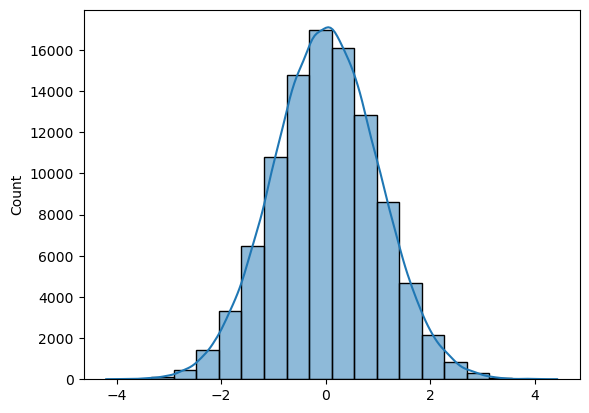

```python
dist1 = np.random.normal(loc=0, scale=1, size = 100000)
sns.histplot(data=dist1, kde=True, bins=20)
```

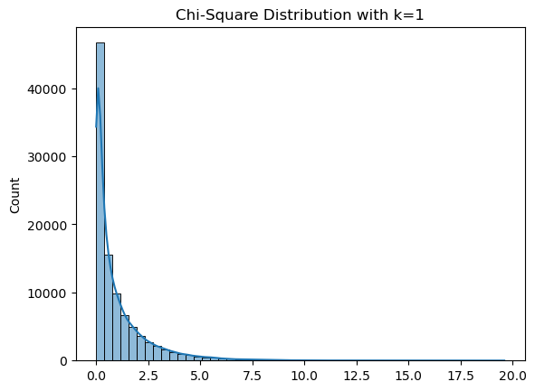

```python
# One Degree Of Freedom, k=1

chi_dist = dist1*dist1 # squaring the random variable
sns.histplot(data=chi_dist, kde=True, bins=50)

plt.title("Chi-Square Distribution with k=1")
plt.show()
```

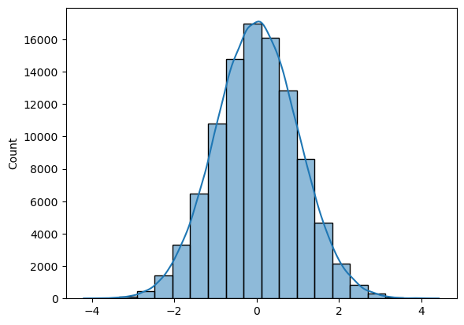

```python
dist2 = np.random.normal(loc=0, scale=1, size = 100000)
sns.histplot(data=dist1, kde=True, bins=20)
```

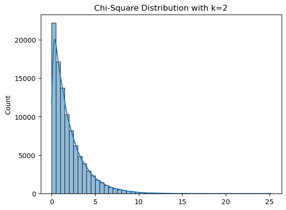

```python
# Two Degree Of Freedom, k=2

chi_dist = (dist1*dist1)+(dist2*dist2) # squaring and adding the random variable from 2 separate distributions
sns.histplot(data=chi_dist, kde=True, bins=50)

plt.title("Chi-Square Distribution with k=2")
plt.show()
```

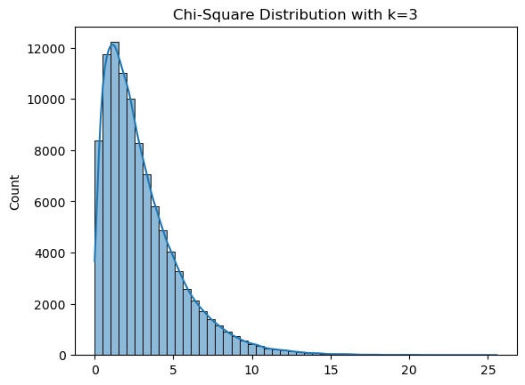

```python
# Three Degree Of Freedom, k=3

dist3 = np.random.normal(loc=0, scale=1, size = 100000)

chi_dist = (dist1*dist1)+(dist2*dist2)+(dist3*dist3)
# squaring and adding the random variables from 3 distributions
sns.histplot(data=chi_dist, kde=True, bins=50)

plt.title("Chi-Square Distribution with k=3")
plt.show()
```

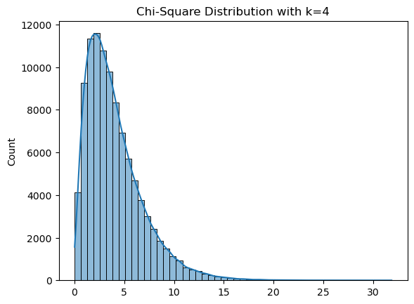

```python
# Four Degree Of Freedom, k=4

dist4 = np.random.normal(loc=0, scale=1, size = 100000)

chi_dist = (dist1*dist1)+(dist2*dist2)+(dist3*dist3)+(dist4*dist4)
# squaring and adding the random variables from 4 distributions
sns.histplot(data=chi_dist, kde=True, bins=50)


plt.title("Chi-Square Distribution with k=4")
plt.show()
```

### With Chi-Square Test we try to find if these separate distributions are related or not.

```
Hence we work with categorical data while computing chi-square test.
```

- If I just take one random variable out of a normal distribution the probability of choosing a number close to 0 is really high (duh!), in additon to that we are squaring it so the resultant number will be a really small number close to 0, hence we see a spike at 0 and the curve gently lowers down at the higher values.
- Same if i take 2 random independent variables, square them and add them up, the probability of the resultant number being close to 0 reduces. hence the curve is more gentle towards 0, and as i take up more random variables, the curve starts to round off on 0.

#### Degree Of Freedom (k)

- In context of Chi-Square Test, when we say k=2, what we mean by that is we are talking about 2 separate distributions.
- For ex, I have 2 distributions of Gender and Choice of Subjects (both normally distributed).
  - They will have 2 separate graphs, 2 separate distributions.
  - Now, if I calculate the chi-square distribution for both of those, they would visually look like what I plotted for k=2.
  - Those 2 categories may have sub-categories amongst them (Gender-Male/Female | Subjects (let's say 5, Hindi, English, Math, Science, Economics), but that is not concern for the moment.
- Also, the Chi-Square value is always positive (also duh!).

#### Aren't Expected Values Subjective?

- Q1. Isn't the expected value subjective? setting aside the mathematical formula, let's say I'm studying gender and choice of college subjects(math, psychology, etc), am i expecting more females to be inclined towards taking the psychology and more men taking up math? are our expected values as per the societial norms?
- A1. Here the meaning of expected values is not what I am expecting as per the norms, rather they are based on independence i.e gender and choice of subjects are unrelated/independent of any norms or nomenclature. We then calculate the difference between the actual data (observed data) and our expected data (independent data) to determine whether or not there is any relation between the two.

# Goodness of Fit Test

- Checks whether our sample distribution is a good fit (good representative) of our population.
- The H0 claims that the sample is a good fit (good representation) of our population.

#### Problem Statement: Whether a demographic distribution of voters in Delhi is the same as the demographic distribution of voters in India.

- Generating some fake data about the people of Delhi and India.

```python
# Population data
india = pd.DataFrame(['white']*100000 + ['hispanic']*60000 + ['black']*50000 + ['asian']*15000 + ['other']*35000)
india_table = pd.crosstab(india[0], columns='count', colnames=['nationality'])

india_table
```

| nationality 0 | count |
| --- | --- |
| asian | 15000 |
| black | 50000 |
| hispanic | 60000 |
| other | 35000 |
| white | 100000 |

```python
# Sample data

delhi = pd.DataFrame(['white']*600 + ['hispanic']*300 + ['black']*250 + ['asian']*75 + ['other']*150)
delhi_table = pd.crosstab(delhi[0], columns='count', colnames=['nationality'])

delhi_table
```

| nationality 0 | count |
| --- | --- |
| asian | 75 |
| black | 250 |
| hispanic | 300 |
| other | 150 |
| white | 600 |

### Calculating Expected Values

#### When to assume equal proportions in the sample

- This depends on the question we are trying to answer. If I want to see if a dice/coin is fair or the probability of drawing cards from the deck or the probability of choosing a specific candy from a bag, in such scenarios it is safe to assume the expected values to be the same for each categories.
  - example, dogs choosing amongst 3 new flavours. We need to assume that the probability of the dogs choosing each flavour is the same and there is no bias there.

#### When to take population proportions

- When we want to answer whether the demographic of my sample represents a population.
  - example, distribuiton of voters in Delhi (sample)
  - distribuiton of voters in India (population)
- In such cases we will be having population proportions from past statistics or we could make up our own.
- Whatever maybe the case of calculating expected values, be sure to state it out clearly before hand.

#### Framing the Hypothesis

- H0: The demographic distribution of voters in Delhi is the same as the demographic distribution of voters in India.
- Ha: The demographic distribution of voters in a Delhi is different from the demographic distribution of voters of India.

#### Using Population Proportions and calculating Manually

```python
prop_table = (india_table/india_table.sum())
prop_table
```

| nationality 0 | count |
| --- | --- |
| asian | 0.057692 |
| black | 0.192308 |
| hispanic | 0.230769 |
| other | 0.134615 |
| white | 0.384615 |

```python
expected_table = delhi_table.sum()*prop_table
expected_table
```

| nationality 0 | count |
| --- | --- |
| asian | 79.326923 |
| black | 264.423077 |
| hispanic | 317.307692 |
| other | 185.096154 |
| white | 528.846154 |

```python
chi_cal = (((delhi_table-expected_table)**2)/expected_table).sum()
chi_cal = chi_cal[0]
print(f"Chi Square value is: {chi_cal}")
```

```
Chi Square value is: 18.194805194805177
```

```python
# Calculating critical values

alpha = 0.05

chi_crit = stats.chi2.ppf(q=1-alpha, # since it is a right tailed test
                      df=4) # df = no. of variable categories - 1

print(f"Chi Critical:  {chi_crit}")

p_value = stats.chi2.cdf(x=chi_cal,
                        df =4)
p_value = 1 - p_value # since it is a right tailed test, by doing this we will be getting the area under right side
print(f"P value: {p_value}")
```

```
Chi Critical:  9.487729036781154
P value: 0.001130467092803511
```

```python
# Presenting our finding using p value.

if p_value<alpha:
    print("There is sufficient statistical evidence to reject the H0.")
    print("The demographic distribution of voters in a Delhi is different from the demographic distribution of voters of India.")
else:
    print("There is sufficient statistical evidence to fail to reject the H0.")
    print("The demographic distribution of voters in a Delhi is the same asthe demographic distribution of voters of India.")
```

```
There is sufficient statistical evidence to reject the H0.
The demographic distribution of voters in a Delhi is different from the demographic distribution of voters of India.
```

```python
# Presenting our finding using chi-square value.

if chi_cal>chi_crit:
    print("There is sufficient statistical evidence to reject the H0.")
    print("The demographic distribution of voters in a Delhi is different from the demographic distribution of voters of India.")
else:
    print("There is sufficient statistical evidence to fail to reject the H0.")
    print("The demographic distribution of voters in a Delhi is the same asthe demographic distribution of voters of India.")
```

```
There is sufficient statistical evidence to reject the H0.
The demographic distribution of voters in a Delhi is different from the demographic distribution of voters of India.
```

#### Calculating Using Python

```python
stats.chisquare(f_obs=delhi_table, # array of observed counts
               f_exp=expected_table) # array of expected counts
```

```
Power_divergenceResult(statistic=array([18.19480519]), pvalue=array([0.00113047]))
```

```python
# Presenting our finding using p value.

if p_value<alpha:
    print("There is sufficient statistical evidence to reject the H0.")
    print("The demographic distribution of voters in a Delhi is different from the demographic distribution of voters of India.")
else:
    print("There is sufficient statistical evidence to fail to reject the H0.")
    print("The demographic distribution of voters in a Delhi is the same asthe demographic distribution of voters of India.")
```

```
There is sufficient statistical evidence to reject the H0.
The demographic distribution of voters in a Delhi is different from the demographic distribution of voters of India.
```

```python
# Presenting our finding using chi-square value.

if chi_cal>chi_crit:
    print("There is sufficient statistical evidence to reject the H0.")
    print("The demographic distribution of voters in a Delhi is different from the demographic distribution of voters of India.")
else:
    print("There is sufficient statistical evidence to fail to reject the H0.")
    print("The demographic distribution of voters in a Delhi is the same asthe demographic distribution of voters of India.")
```

```
There is sufficient statistical evidence to reject the H0.
The demographic distribution of voters in a Delhi is different from the demographic distribution of voters of India.
```

# Independence Test

- Checks whether two variables are related to each other or not.
- Describes a situation where knowing the value of one variable tells you nothing about the value of another
- For example, the month you were born in tells you nothing about which phone you use.
- In this case we'd expect your birth month to be independent of your phone preference.
- This test is used if education, political views, etc vary based on demographic factors like gender, race, religion etc.
- The H0 (Null Hypothesis) here claims that there is no relationship between the 2 variables, i.e. they are statistically independent, this is potrayed by the expected values.
- The Ha (Alternate Hypothesis) here claims that there is a relationship between the 2 variables, i.e. they are not statistically independent.
- Rejecting the Null Hypothesis, means we are claiming here that the 2 variables are indeed related/dependent.
- Failing to reject the Null Hypothesis, means we are claiming here that the 2 variables are unrelated/independent.

#### Using tips dataset for this

```python
df = sns.load_dataset('tips')
```

```python
df.head()
```

|  | total_bill | tip | sex | smoker | day | time | size |
| --- | --- | --- | --- | --- | --- | --- | --- |
| 0 | 16.99 | 1.01 | Female | No | Sun | Dinner | 2 |
| 1 | 10.34 | 1.66 | Male | No | Sun | Dinner | 3 |
| 2 | 21.01 | 3.50 | Male | No | Sun | Dinner | 3 |
| 3 | 23.68 | 3.31 | Male | No | Sun | Dinner | 2 |
| 4 | 24.59 | 3.61 | Female | No | Sun | Dinner | 4 |

### Checking the relationship between sex and smoker.

#### Framing The Hypothesis

- H0: The gender and the smoking habits of a person are independent.
- Ha: The gender and the smoking habits of a person are not independent.

```python
obs_df = pd.crosstab(df['sex'], df['smoker'])
obs_df
```

| smoker sex | Yes | No |
| --- | --- | --- |
| Male | 60 | 97 |
| Female | 33 | 54 |

```python
stats.chi2_contingency(obs_df, correction=False)
```

```
Chi2ContingencyResult(statistic=0.001934818536627623, pvalue=0.964915107315732, dof=1, expected_freq=array([[59.84016393, 97.15983607],
       [33.15983607, 53.84016393]]))
```

```python
chi_cal, pval, df, exp_freq = stats.chi2_contingency(obs_df, correction=False)

print(f"Chi Cal: {chi_cal}")
print(f"P Value: {pval}")
```

```
Chi Cal: 0.001934818536627623
P Value: 0.964915107315732
```

```python
# calculating critical chi square

alpha = 0.05
chi_cri = stats.chi2.ppf(q=0.95,
              df = 1)

print(f"Chi Cri: {chi_cri}")
```

```
Chi Cri: 3.841458820694124
```

```python
# Presenting our findings using p value.

if pval<alpha:
    print("There is sufficient statistical evidence to reject the H0.")
    print("The gender and the smoking habits of a person are not independent.")
else:
    print("There is sufficient statistical evidence to fail to reject the H0.")
    print("The gender and the smoking habits of a person are independent.")
```

```
There is sufficient statistical evidence to fail to reject the H0.
The gender and the smoking habits of a person are independent.
```

```python
# Presenting our findings using chi-square value.

if chi_cal>chi_cri:
    print("There is sufficient statistical evidence to reject the H0.")
    print("The gender and the smoking habits of a person are not independent.")
else:
    print("There is sufficient statistical evidence to fail to reject the H0.")
    print("The gender and the smoking habits of a person are independent.")
```

```
There is sufficient statistical evidence to fail to reject the H0.
The gender and the smoking habits of a person are independent.
```

#### Is Chi-Square Test a one sided or a two sided test?

- When a chi-square value is way out on the right side, it indicates our sample is a poor fit of our population. If it is too far right (over the threshold value) we conclude that the fit is so poor that it is not a representative of our population at all.
- If we were to use a two-tailed chi-square test, we would also be worried whether the chi-square statistic is too far on the left, indicating too good of a fit, which is something we are not worried about.
- Also since chi-square is the square of our z score, a two tailed p-value of a z score = 2 or (-2) is 0.045
- And a one tailed p value of a chi-square = 4 is 0.045.
- In short, a chi-square test is used to see if our sample is a good fit (good representative) of our population.
- We are not concerned by what magnitude it is different, if at all.